# code

#### Continous Numerical Variable

```python
continous_feature = [feature for feature in numerical_features if feature not in discrete_features + year_feature + ['id'] + ['date']]
print(f"Continous feature count : {len(continous_feature)}")
```

```
Continous feature count : 10
```

```python
continous_feature
```

```
['price',
 'sqft_living',
 'sqft_lot',
 'sqft_above',
 'sqft_basement',
 'zipcode',
 'lat',
 'long',
 'sqft_living15',
 'sqft_lot15']
```

```python
continous_feature.remove('lat')
continous_feature.remove('long')
continous_feature.remove('zipcode')
```

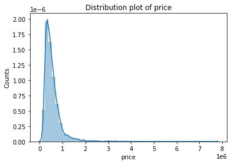

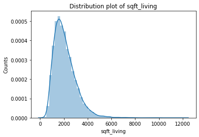

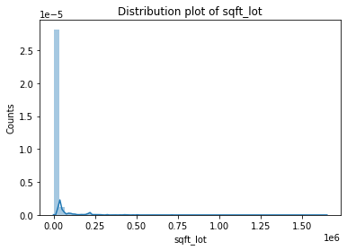

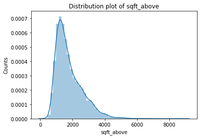

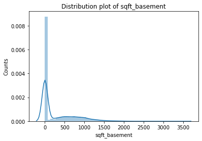

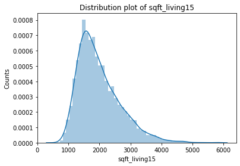

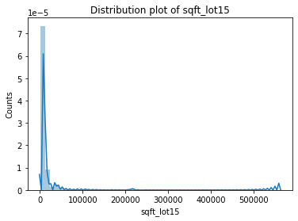

```python
#let us understand continous features by plotting distribution plot

for feature in continous_feature:
    df = train.copy()
    sns.distplot(df[feature])
    plt.xlabel(feature)
    plt.ylabel("Counts")
    plt.title(f"Distribution plot of {feature}")
    plt.show()
```

As we can clearly see that the distribution for all of these variables is skewed and they do not follow normal distribution. For our regression problem it is always better to convert these non normal distribution to normal distribution to improve our linear prediction.

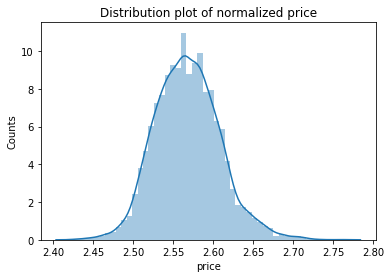

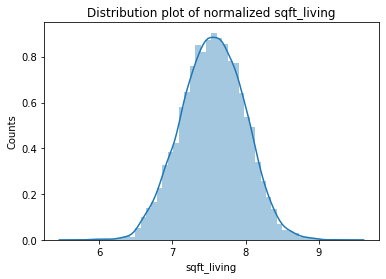

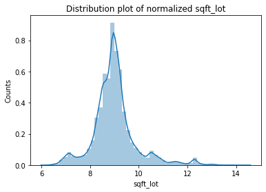

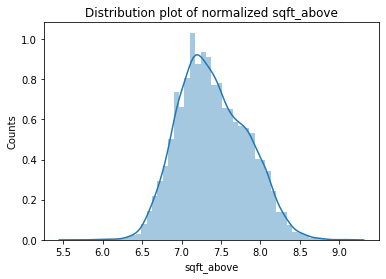

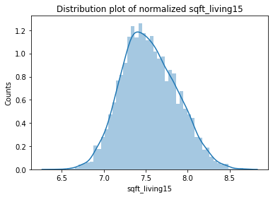

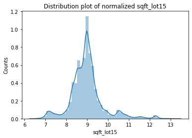

```python
#using logarathmic transformation on the continous variable
#to remove the skew and tend them to a normal distribution

for feature in continous_feature:
    df = train.copy()
    if 0 in df[feature].unique():
        pass
    else:
        df[feature] = np.log(df[feature])
        df['price'] = np.log(df['price'])
        sns.distplot(df[feature])
        plt.xlabel(feature)
        plt.ylabel("Counts")
        plt.title(f"Distribution plot of normalized {feature}")
        plt.show()
```

Now we can see clearly all the sqft variables now are close to a normal distribution. Log transformation is not possible on the Square Feet Basement variable, as most of the houses do not have a basement, and thus have a 0 value for the variable.

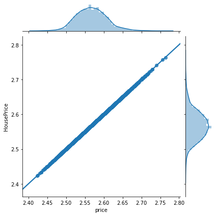

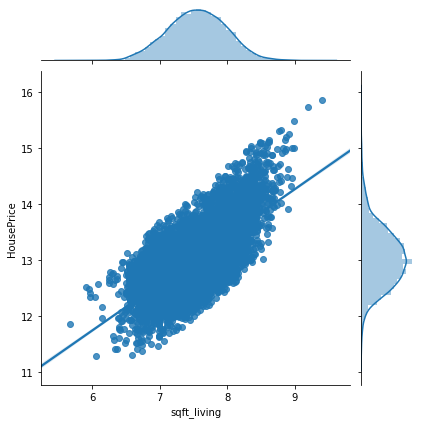

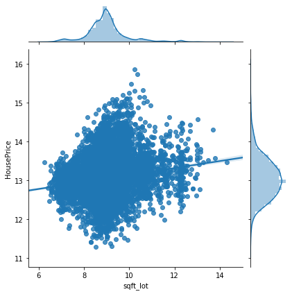

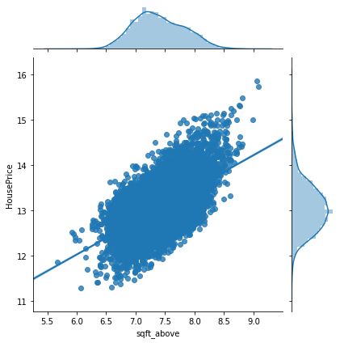

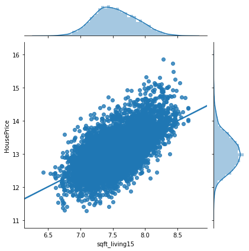

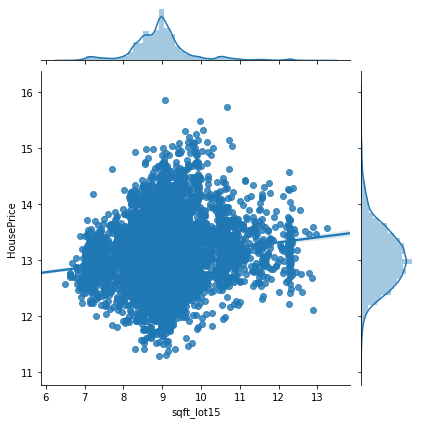

```python
#Plotting a scatter plot between continous variable and target variable
#the continous varibale are normalized.

for feature in continous_feature:
    df = train.copy()
    if 0 in df[feature].unique():
        pass
    else:
        df[feature] = np.log(df[feature])
        df['price'] = np.log(df['price'])
        sns.jointplot(x = feature, y = 'price', data = df, kind = "reg")
        plt.xlabel(feature)
        plt.ylabel("HousePrice")
        plt.show()
```

Conclusions from above plot:  
--> There is a strong linear relationship between sqft_living and houseprice.  
--> Even with the normalized sqft_lot column, there’s a VERY limited linear relationship.  
--> There is a strong linear relationship between sqft_above and houseprice.  
--> the relation is same for sqft15 living with sqft living and sqft lot and sqft 15 lot.

### Location variables

```python
location_variable = ['zipcode', 'lat', 'long']
```

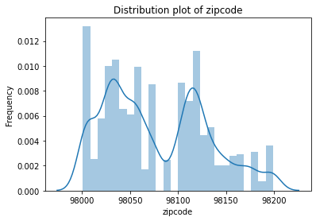

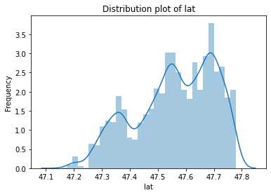

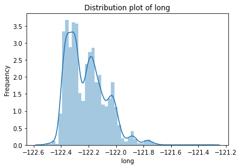

```python
#let us understand location features by plotting distribution plot
for feature in location_variable:
    df = train.copy()
    sns.distplot(df[feature])
    plt.title(f"Distribution plot of {feature}")
    plt.xlabel(feature)
    plt.ylabel("Frequency")
    plt.show()
```

Conclusions from above plot:  
--> Train dataset pincode are ranging from 98000 to 98200.  
--> Train dataset has a coverage from -122.4 to -121.2 for long variable.  
--> Train dataset has a coverage from 47.0 to 47.75 for lat variable.

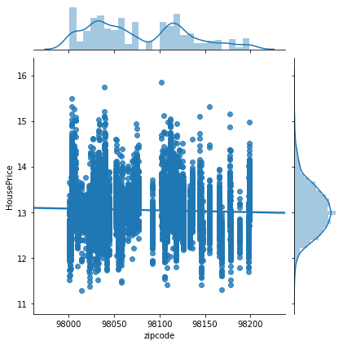

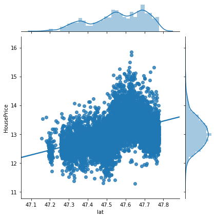

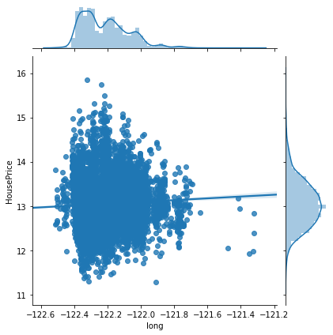

```python
#let us plot location variable with respect to price.
for feature in location_variable:
    df = train.copy()
    df['price'] = np.log(df['price'])
    sns.jointplot(x = feature, y = 'price', data = df, kind = "reg")
    plt.xlabel(feature)
    plt.ylabel("HousePrice")
    plt.show()
```

### Outliers

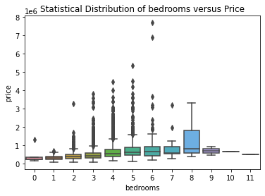

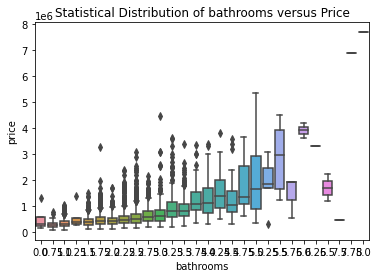

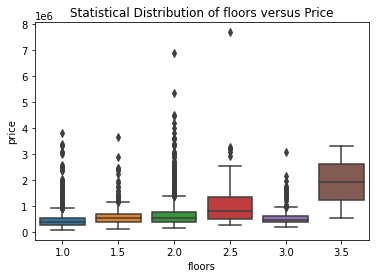

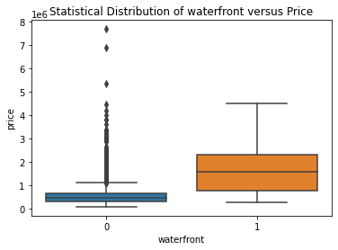

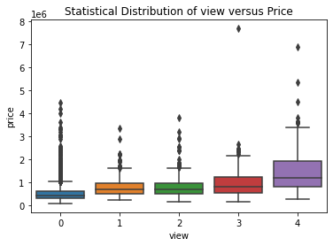

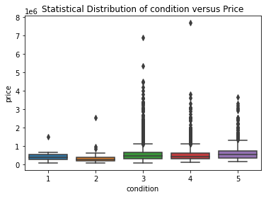

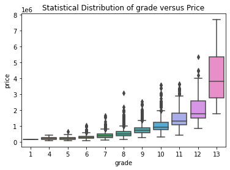

```python
#Determining outliers

for feature in discrete_features:
    df = train.copy()
    sns.boxplot(x = feature, y = "price", data = df)
    plt.title(f"Statistical Distribution of {feature} versus Price")
    plt.show()
```

Here we have determined outliers with respect to price for discrete features.